# Dados sobre séries de TV

Analisaremos os episódios das séries Black Mirror, Breaking Bad e Orphan Black.

```r
episodes = read_csv(here("data/series_from_imdb.csv"),
                    progress = FALSE,
                    col_types = cols(.default = col_double(),
                                     series_name = col_character(),
                                     episode = col_character(),
                                     url = col_character(),
                                     season = col_character())) %>%
    filter(series_name %in% c("Orphan Black", "Black Mirror", "Breaking Bad"))
```

### Qual das séries que você escolheu é mais bem avaliada no IMDB? A diferença é grande? Pequena? Muda de acordo com as temporadas da série?

Para responder essas perguntas precisaremos analisar a avaliação feita pelos usuários para os episódios de cada série. Nesse gráfico são utilizadas as medianas das avaliações das temporadas.

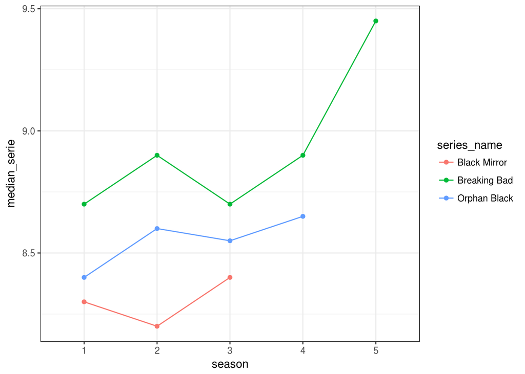

```r
data_median <- episodes %>%
    group_by(series_name, season) %>%
    summarise(median_serie = median(user_rating))


ggplot(data = data_median,  aes(x = season, y = median_serie, color = series_name, group=series_name)) +
geom_line(stat='identity') +
     geom_point()
```

Através desse gráfico é possível perceber que a série mais bem avaliada no IMDB é Breaking Bad. Para verificar se a diferença entre as outras é grande, iremos calcular a média dos pontos obtidos através do gráfico:

```r
data_median %>%
    group_by(series_name) %>%
    summarise(media = mean(median_serie))
```

| series_name | media |
| --- | --- |
| Black Mirror | 8.30 |
| Breaking Bad | 8.93 |
| Orphan Black | 8.55 |

Dessa forma, concluímos que não há uma diferença muito grande com relação as outras séries. Além disso, observamos que os pontos do gráfico não seguem um padrão contínuo, ou seja, as avaliações estão variando de acordo com as temporadas.

### Qual das séries que você escolheu tem episódios de qualidade mais irregular segundo o IMDB? A diferença é grande? Pequena?

Para obter essa resposta, vamos calcular o desvio padrão das medianas encontradas no gráfico anterior.  
- **Black Mirror**:

```r
medians_BM <- data_median %>%
    filter(series_name %in% c("Black Mirror"))
med_BM = medians_BM$median_serie
sd(med_BM)
```

```
[1] 0.1
```

- **Breaking Bad**:

```r
medians_BB <- data_median %>%
    filter(series_name %in% c("Breaking Bad"))
med_BB = medians_BB$median_serie
sd(med_BB)
```

```
[1] 0.3074085
```

- **Orphan Black**:

```r
medians_OB <- data_median %>%
    filter(series_name %in% c("Orphan Black"))
med_OB = medians_OB$median_serie
sd(med_OB)
```

```
[1] 0.1080123
```

Ou seja, Breaking Bad possui mais episódios de qualidade mais irregular segundo o IMDB, pois um alto desvio padrão indica que os pontos dos dados estão espalhados por uma ampla gama de valores. A diferença dessa entre as outras duas é grande, mas das outras duas entre si é pequena.

### Qual das séries ou temporadas tem episódios mais sem graça? (Um episódio é sem graça se ninguém nem ama nem odeia ele)

Os boxplots contruídos para encontrar essa resposta foi montado com base no somatório da proporção de usuários que avaliaram o episódio com os valores 4, 5 ou 6. Nesse caso, estamos avaliando todos os episódios de cada série, então iremos descobrir qual das séries tem episódios mais sem graça.

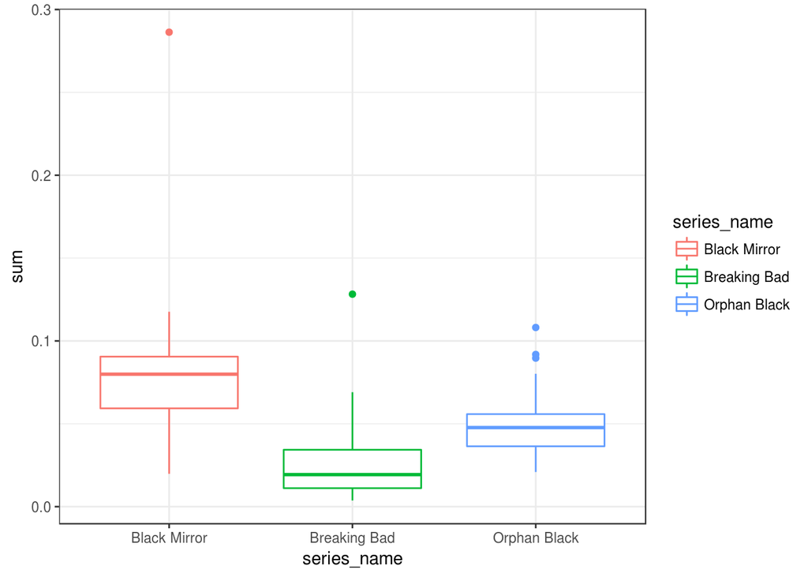

```r
data_not_funny <- episodes %>%
    group_by(series_name, episode) %>%
    summarise(sum = r4+r5+r6)

ggplot(data = data_not_funny,  aes(x = series_name, y = sum, color = series_name, group=series_name)) +
geom_boxplot()
```

Pela distribuição dos dados mostrados nos boxplots, obtemos o seguinte ranking de séries que tem episódios mais sem graça:  
**1º Black Mirror**  
**2º Orphan Black**  
**3º Breaking Bad**  
Essa conclusão é feita com base na linha da mediana de cada boxplot, dessa forma, a proporção de usuários que avaliaram os episódios de Black Mirror com os valores 4, 5 ou 6 é a maior dentre as 3 séries.

## Qual a distribuição da avaliação dos episódios?

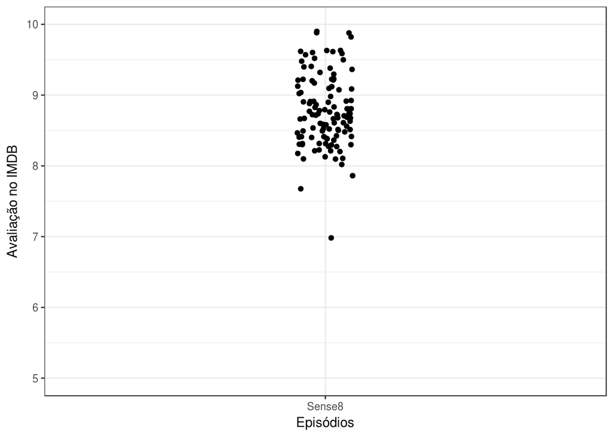

```r
episodes %>%
    ggplot(aes(x = "Sense8", y = user_rating)) +
    geom_jitter(width = .05) +
    ylim(5, 10) +
    labs(x = "Episódios", y = "Avaliação no IMDB")
```

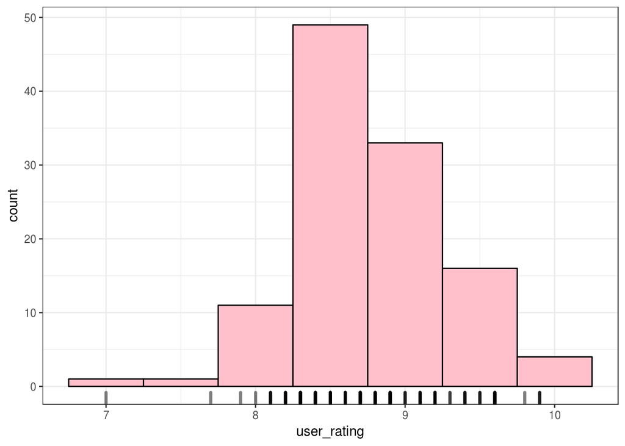

```r
episodes %>%
    ggplot(aes(x = user_rating)) +
    geom_histogram(binwidth = .5, fill = "pink", color = "black") +
    geom_rug(alpha = .5, size = 1.2)
```

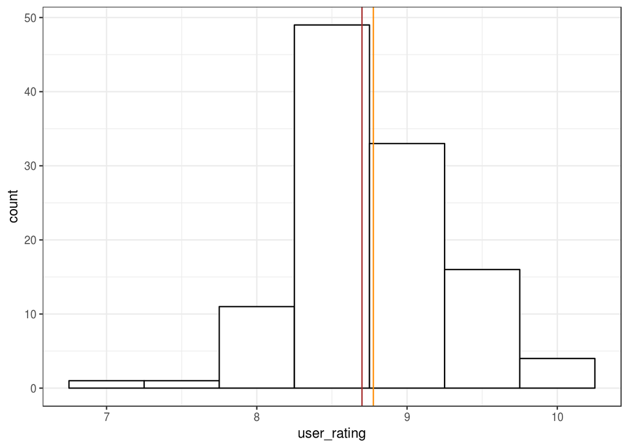

```r
sumarios = episodes %>%
    summarise(mediana = median(user_rating),
              media = mean(user_rating))

episodes %>%
    ggplot(aes(x = user_rating)) +
    geom_histogram(binwidth = .5, fill = "white", color = "black") +
    geom_vline(xintercept = sumarios$media, color = "darkorange") +
    geom_vline(xintercept = sumarios$mediana, color = "brown")
```

### Qual é esse episódio pior avaliado?

```r
episodes %>%
    filter(user_rating == min(user_rating))
```

| series_name | episode | series_ep | season | season_ep | url | user_rating | user_votes | r1 | r2 | r3 | r4 | r5 | r6 | r7 | r8 | r9 | r10 |
| --- | --- | --- | --- | --- | --- | --- | --- | --- | --- | --- | --- | --- | --- | --- | --- | --- | --- |
| Black Mirror | The Waldo Moment | 6 | 2 | 3 | http://www.imdb.com/title/tt2542420/ | 7 | 9392 | 0.008072827 | 0.004809344 | 0.007128135 | 0.008502233 | 0.02293026 | 0.05908622 | 0.1527825 | 0.2587599 | 0.2518894 | 0.2260392 |

## Qual a pior/melhor temporada segundo o IMDB?

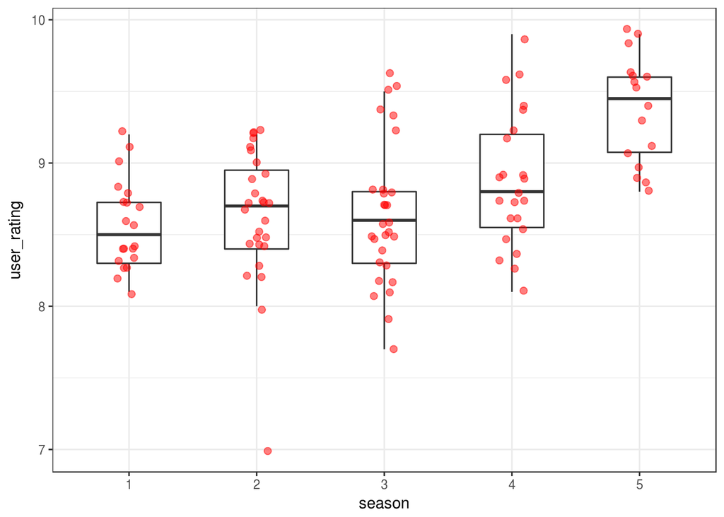

```r
episodes %>%
    ggplot(aes(x = season, y = user_rating)) +
    geom_boxplot(width = .5, outlier.color = NA) +
    geom_jitter(width = .1, size = 2, alpha = .5, color = "red")
```

### Há padrões na avaliação ao longo do tempo?

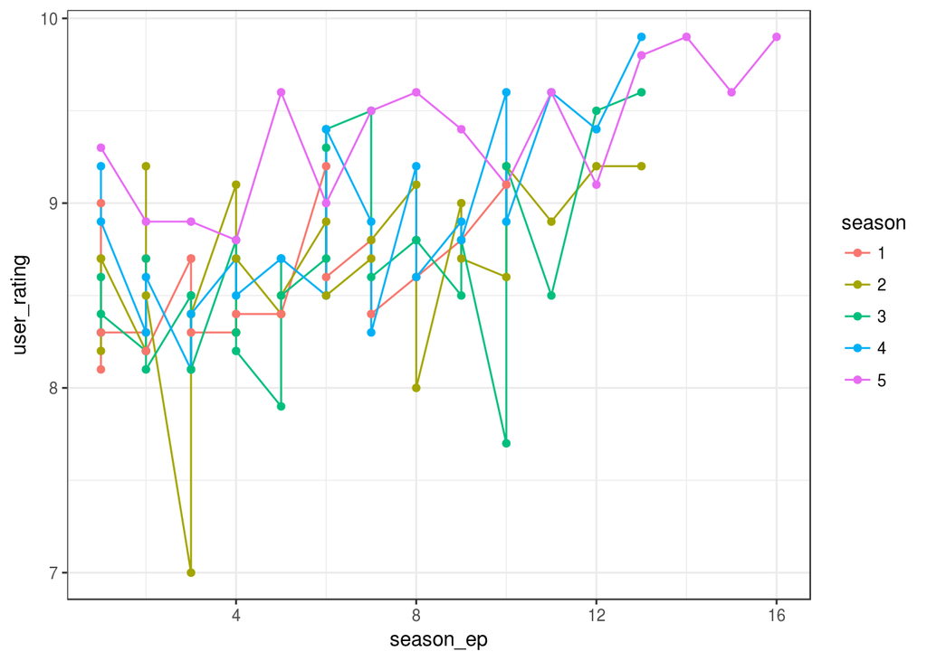

```r
episodes %>%
  ggplot(aes(x = season_ep, y = user_rating, color = season)) +
  geom_line() +
  geom_point()
```

Correlações

```r
episodes %>%
    group_by(season) %>%
    summarise(correlacao_linear = cor(season_ep, user_rating,
                                      method = "pearson"),
              correlacao_kendall = cor(season_ep, user_rating,
                                       method = "kendall"))
```

| season | correlacao_linear | correlacao_kendall |
| --- | --- | --- |
| 1 | 0.4766481 | 0.4114554 |
| 2 | 0.4499861 | 0.3824191 |
| 3 | 0.4788627 | 0.3759804 |
| 4 | 0.6307209 | 0.4615634 |
| 5 | 0.6889554 | 0.5458690 |

## Qual o episódio mais detestado?

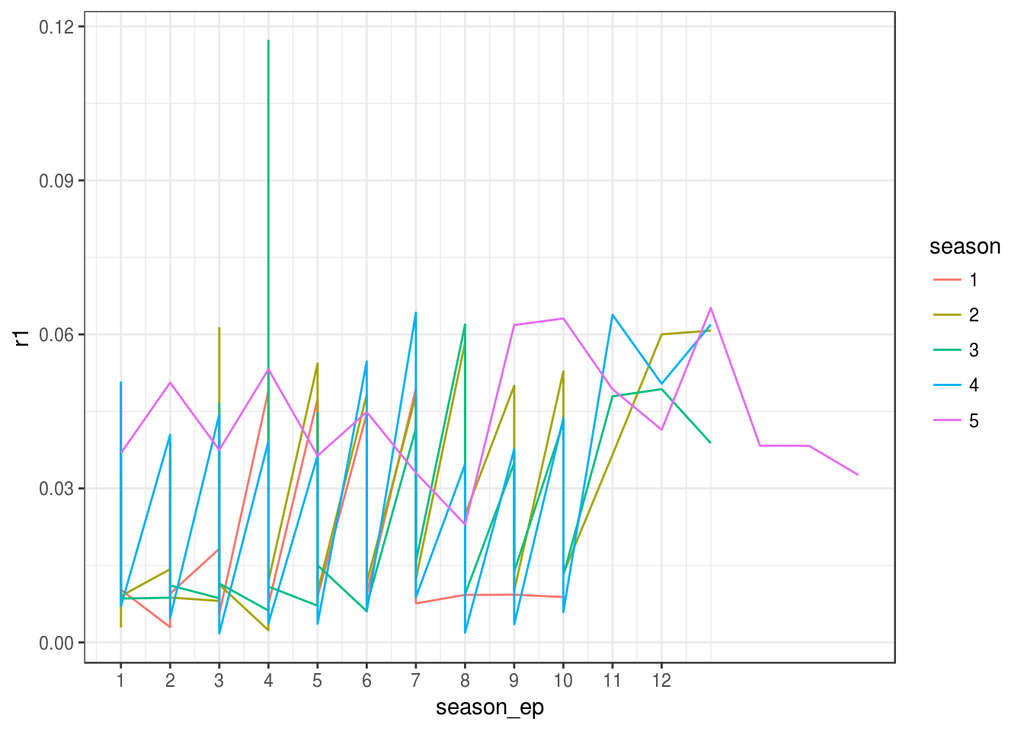

```r
episodes %>%
    ggplot(aes(x = season_ep, y = r1, color = season)) +
    geom_line() +
    scale_x_continuous(breaks = 1:12)
```

### E amado?

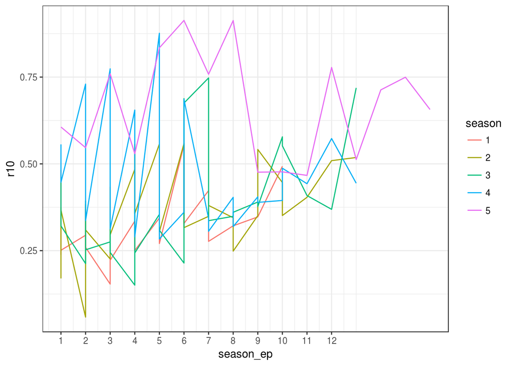

```r
episodes %>%
    ggplot(aes(x = season_ep, y = r10, color = season)) +
    geom_line() +
    scale_x_continuous(breaks = 1:12)
```

### Amor e ódio andam juntos?

Quais são episódios que estão entre os mais amados e mais odiados?

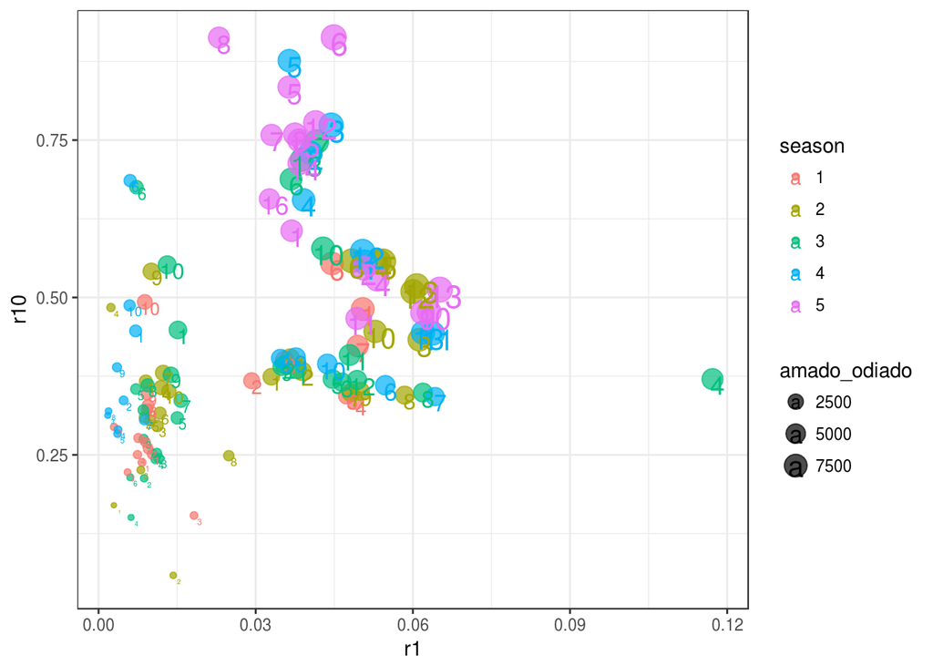

```r
episodes =  episodes %>%
    mutate(
        rank_odiados = row_number(r1), # maior = mais odiado
        rank_amados = row_number(r10), # maior = mais amado
        amado_odiado = rank_amados * rank_odiados) # maior = mais amado E odiado

episodes %>%
    ggplot(aes(
        x = r1,
        y = r10,
        color = season,
        size = amado_odiado,
        label = season_ep
    )) +
    geom_point(alpha = .7) +
    geom_text(nudge_x = .001, nudge_y = -.01)
```

```r
episodes %>%
    arrange(-amado_odiado)
```

| series_name | episode | series_ep | season | season_ep | url | user_rating | user_votes | r1 | r2 | r3 | r4 | r5 | r6 | r7 | r8 | r9 | r10 | rank_odiados | rank_amados | amado_odiado |
| --- | --- | --- | --- | --- | --- | --- | --- | --- | --- | --- | --- | --- | --- | --- | --- | --- | --- | --- | --- | --- |
| Breaking Bad | Buyout | 52 | 5 | 6 | http://www.imdb.com/title/tt2301451/ | 9.0 | 9790 | 0.044895176 | 0.0015340037 | 0.0008749503 | 0.0008181353 | 0.001534004 | 0.001658997 | 0.002954378 | 0.008533606 | 0.02393046 | 0.91326629 | 84 | 115 | 9660 |
| Breaking Bad | To'hajiilee | 59 | 5 | 13 | http://www.imdb.com/title/tt2301465/ | 9.8 | 21643 | 0.065148576 | 0.0023486164 | 0.0017359338 | 0.0033697539 | 0.005309915 | 0.008066987 | 0.035127132 | 0.129786582 | 0.23659757 | 0.51250893 | 114 | 84 | 9576 |
| Breaking Bad | Breakage | 12 | 2 | 5 | http://www.imdb.com/title/tt1232248/ | 8.4 | 8036 | 0.054325741 | 0.0023526896 | 0.0026735109 | 0.0028873917 | 0.007378890 | 0.008769116 | 0.030584964 | 0.101593412 | 0.23216768 | 0.55726660 | 102 | 93 | 9486 |
| Breaking Bad | Down | 11 | 2 | 4 | http://www.imdb.com/title/tt1232247/ | 8.3 | 8211 | 0.053454036 | 0.0024787154 | 0.0025864856 | 0.0022631749 | 0.005496282 | 0.007436146 | 0.029097963 | 0.101842871 | 0.23892661 | 0.55641772 | 101 | 92 | 9292 |
| Breaking Bad | End Times | 45 | 4 | 12 | http://www.imdb.com/title/tt1683095/ | 9.4 | 10367 | 0.050397878 | 0.0028735632 | 0.0016578249 | 0.0025419982 | 0.005083996 | 0.005857648 | 0.027630416 | 0.101458886 | 0.22955349 | 0.57294430 | 95 | 95 | 9025 |
| Breaking Bad | ABQ | 20 | 2 | 13 | http://www.imdb.com/title/tt1232256/ | 9.2 | 9347 | 0.060739154 | 0.0024638457 | 0.0023567220 | 0.0022495983 | 0.006320300 | 0.010712373 | 0.039421532 | 0.118478843 | 0.23888591 | 0.51837172 | 106 | 85 | 9010 |
| Breaking Bad | Box Cutter | 34 | 4 | 1 | http://www.imdb.com/title/tt1683084/ | 9.2 | 9988 | 0.050840673 | 0.0024019215 | 0.0027021617 | 0.0025020016 | 0.007506005 | 0.008606886 | 0.029323459 | 0.100980785 | 0.23899119 | 0.55614492 | 98 | 91 | 8918 |
| Breaking Bad | Open House | 36 | 4 | 3 | http://www.imdb.com/title/tt1683086/ | 8.1 | 7905 | 0.044408736 | 0.0021181798 | 0.0021181798 | 0.0014608137 | 0.002848587 | 0.002629465 | 0.009714411 | 0.034913447 | 0.12599518 | 0.77379300 | 81 | 110 | 8910 |
| Breaking Bad | Phoenix | 19 | 2 | 12 | http://www.imdb.com/title/tt1232255/ | 9.2 | 9276 | 0.060008482 | 0.0018023749 | 0.0020144190 | 0.0029686175 | 0.004664970 | 0.007209500 | 0.032972858 | 0.129452926 | 0.24957591 | 0.50932994 | 105 | 83 | 8715 |
| Breaking Bad | Buried | 56 | 5 | 10 | http://www.imdb.com/title/tt2301459/ | 9.1 | 11362 | 0.063099126 | 0.0021068155 | 0.0030548825 | 0.0022121563 | 0.006847151 | 0.009691352 | 0.048772780 | 0.152112083 | 0.23512062 | 0.47698304 | 111 | 78 | 8658 |

[output cut: 105 more lines]